# Tipología y Ciclo de Vida de Datos

# PEC 4 - Análisis de varianza y repaso

Autores : Pablo Román-Naranjo Varela y Adrián Vicente Gómez

Enero 2021

# 1 Descripción del dataset

El dataset utilizado, fifa.csv, está disponible en Kaggle: https://www.kaggle.com/artimous/complete-fifa-2017-player-dataset-global. Este dataset contiene las **estadísticas de los jugadores en el videojuego Fifa 17**. Contiene 17588 filas con 53 variables diferentes para describir a cada jugador. Entre estas variables nos encontramos con las siguientes:

- Name (Nombre del jugador)
- Nationality (Nacionalidad del jugador)
- National_Position (Posición de juego en equipo nacional).
- National_Kit (Número de equipación en equipo nacional)
- Club (Nombre del club)
- Club_Position (Posición de juego en club)
- Club_Kit (Número de equipación en club)
- Club_Joining (Fecha en la que empezó en el club)
- Contract_Expire (Año finalización del contrato)
- Rating (Valoración global del jugador, entre 0 y 100)
- Height (Altura)
- Weight (Peso)
- Preffered_Foot (Pie preferido)
- Birth_Date (Fecha de nacimiento)
- Age (Edad)
- Preffered_Position (Posición preferida)
- Work_Rate (valoración cualitativa en términos de ataque-defensa)
- Weak_foot (valoración de 1 a 5 de control y potencia de la pierna no preferida)
- Skill_Moves (valoración de 1 a 5 de la habilidad en movimientos del jugador)
- El resto de variables son los distintos atributos que definen a un jugador en este juego.

En la actualidad, el fútbol forma parte de nuestra vida cotidiana y es el **deporte con un mayor impacto social**. Aunque no deja de ser un videojuego, FIFA maneja tantos detalles sobre los jugadores que los ojeadores y los empleados de los clubes lo usan como herramienta para buscar nuevos jugadores que de otra manera no podrían ver. Por ello, realizar un análisis estadístico de los datos de este juego podría permitir arrojar cordura por encima de los sentimientos a la hora de tomar diferentes decisiones. Como ejemplo de estos análisis, **en este documento se planteará**:

- Si en el año 2017, la diferencia entre valoración global entre los jugadores del Real Betis y el Real Madrid era mayor a 5 puntos.
- Si existe correlación entre la media de un jugador y el hecho de que sea convocado o no con su selección nacional.
- Obtener un modelo de regresión que nos permita estimar la valoración de un jugador a partir de un subjconjunto de sus atributos.

# 2 Intregración y selección de datos de interés a analizar

Se carga el archivo usando la función **read.csv()**, con el separador como coma. Además, se especifica que archivo está **codificado en UTF** para que pueda leer de manera correcta los caracteres especiales como tildes o diéresis.

```r
datos = read.csv("../data/fifa.csv", header=T, sep=",", fileEncoding = "UTF-8")

# inspeccionamos el dataset
head(datos)
```

```
##                Name Nationality National_Position National_Kit           Club
## 1 Cristiano Ronaldo    Portugal                LS            7    Real Madrid
## 2      Lionel Messi   Argentina                RW           10   FC Barcelona
## 3            Neymar      Brazil                LW           10   FC Barcelona
## 4       Luis Suárez     Uruguay                LS            9   FC Barcelona
## 5      Manuel Neuer     Germany                GK            1      FC Bayern
## 6            De Gea       Spain                GK            1 Manchester Utd
##   Club_Position Club_Kit Club_Joining Contract_Expiry Rating Height Weight
## 1            LW        7   07/01/2009            2021     94 185 cm  80 kg
## 2            RW       10   07/01/2004            2018     93 170 cm  72 kg
## 3            LW       11   07/01/2013            2021     92 174 cm  68 kg
## 4            ST        9   07/11/2014            2021     92 182 cm  85 kg
## 5            GK        1   07/01/2011            2021     92 193 cm  92 kg
## 6            GK        1   07/01/2011            2019     90 193 cm  82 kg
##   Preffered_Foot Birth_Date Age Preffered_Position       Work_Rate Weak_foot
```

[output cut: 48 more lines]

Usando el comando **head()** se inspeccionan las primeras líneas del fichero, y se observa que se ha asignado correctamente el nombre de cada variable.

Para ver qué tipo de datos se asigna a cada variable se utiliza la función **str()**.

```r
str(datos)
```

```
## 'data.frame':    17588 obs. of  53 variables:
##  $ Name              : chr  "Cristiano Ronaldo" "Lionel Messi" "Neymar" "Luis Suárez" ...
##  $ Nationality       : chr  "Portugal" "Argentina" "Brazil" "Uruguay" ...
##  $ National_Position : chr  "LS" "RW" "LW" "LS" ...
##  $ National_Kit      : num  7 10 10 9 1 1 9 11 NA 1 ...
##  $ Club              : chr  "Real Madrid" "FC Barcelona" "FC Barcelona" "FC Barcelona" ...
##  $ Club_Position     : chr  "LW" "RW" "LW" "ST" ...
##  $ Club_Kit          : num  7 10 11 9 1 1 9 11 9 13 ...
##  $ Club_Joining      : chr  "07/01/2009" "07/01/2004" "07/01/2013" "07/11/2014" ...
##  $ Contract_Expiry   : num  2021 2018 2021 2021 2021 ...
##  $ Rating            : int  94 93 92 92 92 90 90 90 90 89 ...
##  $ Height            : chr  "185 cm" "170 cm" "174 cm" "182 cm" ...
##  $ Weight            : chr  "80 kg" "72 kg" "68 kg" "85 kg" ...
##  $ Preffered_Foot    : chr  "Right" "Left" "Right" "Right" ...
##  $ Birth_Date        : chr  "02/05/1985" "06/24/1987" "02/05/1992" "01/24/1987" ...
```

[output cut: 39 more lines]

Como se ve, se dispone de **53 variables** que describen a cada jugador, y el tipo en el que se han cargado.

# 3 Limpieza de los datos

## 3.1 Análisis de valores ausentes

Para realizar un análisis de los datos, realizamos un resumen de los mismos con la función **summary()**.

```r
summary(datos)
```

```
##      Name           Nationality        National_Position   National_Kit
##  Length:17588       Length:17588       Length:17588       Min.   : 1.00
##  Class :character   Class :character   Class :character   1st Qu.: 6.00
##  Mode  :character   Mode  :character   Mode  :character   Median :12.00
##                                                           Mean   :12.22
##                                                           3rd Qu.:18.00
##                                                           Max.   :36.00
##                                                           NA's   :16513
##      Club           Club_Position         Club_Kit     Club_Joining
##  Length:17588       Length:17588       Min.   : 1.00   Length:17588
##  Class :character   Class :character   1st Qu.: 9.00   Class :character
##  Mode  :character   Mode  :character   Median :18.00   Mode  :character
##                                        Mean   :21.29
##                                        3rd Qu.:27.00
##                                        Max.   :99.00
##                                        NA's   :1
##  Contract_Expiry     Rating         Height             Weight
##  Min.   :2017    Min.   :45.00   Length:17588       Length:17588
##  1st Qu.:2017    1st Qu.:62.00   Class :character   Class :character
##  Median :2019    Median :66.00   Mode  :character   Mode  :character
##  Mean   :2019    Mean   :66.17
##  3rd Qu.:2020    3rd Qu.:71.00
##  Max.   :2023    Max.   :94.00
##  NA's   :1
##  Preffered_Foot      Birth_Date             Age        Preffered_Position
##  Length:17588       Length:17588       Min.   :17.00   Length:17588
##  Class :character   Class :character   1st Qu.:22.00   Class :character
##  Mode  :character   Mode  :character   Median :25.00   Mode  :character
##                                        Mean   :25.46
##                                        3rd Qu.:29.00
##                                        Max.   :47.00
##
##   Work_Rate           Weak_foot      Skill_Moves     Ball_Control
##  Length:17588       Min.   :1.000   Min.   :1.000   Min.   : 5.00
##  Class :character   1st Qu.:3.000   1st Qu.:2.000   1st Qu.:53.00
##  Mode  :character   Median :3.000   Median :2.000   Median :63.00
##                     Mean   :2.934   Mean   :2.303   Mean   :57.97
##                     3rd Qu.:3.000   3rd Qu.:3.000   3rd Qu.:69.00
##                     Max.   :5.000   Max.   :5.000   Max.   :95.00
##
```

[output cut: 49 more lines]

```
##  Min.   : 7.00   Min.   : 3.00   Min.   : 1.00   Min.   : 1.00
##  1st Qu.:39.00   1st Qu.:30.00   1st Qu.: 8.00   1st Qu.: 8.00
##  Median :50.00   Median :44.00   Median :11.00   Median :11.00
##  Mean   :49.17   Mean   :43.28   Mean   :16.61   Mean   :16.82
##  3rd Qu.:61.00   3rd Qu.:57.00   3rd Qu.:14.00   3rd Qu.:14.00
##  Max.   :96.00   Max.   :93.00   Max.   :91.00   Max.   :89.00
##
##    GK_Kicking     GK_Handling     GK_Reflexes
##  Min.   : 1.00   Min.   : 1.00   Min.   : 1.0
##  1st Qu.: 8.00   1st Qu.: 8.00   1st Qu.: 8.0
##  Median :11.00   Median :11.00   Median :11.0
##  Mean   :16.46   Mean   :16.56   Mean   :16.9
##  3rd Qu.:14.00   3rd Qu.:14.00   3rd Qu.:14.0
##  Max.   :95.00   Max.   :91.00   Max.   :90.0
##
```

Si se observa el resumen realizado, en él es posible estudiar **qué variables disponen de valores ausentes**, marcados como NA’s. En este caso, de **las variables numéricas referentes a estadísticas** de jugadores, **ninguna muestra valores ausentes**.

Donde sí se pueden observar **valores ausentes es en las variables National_Kit, National_Position, Club_Kit y Contract_Expiry**. En el caso de las dos primeras variables, National_Kit y National_Position, es normal la existencia de valores nulos, ya que solo encontraremos un valor en estas variables si el jugador forma parte actualmente de la selección de su país. En las otras dos variables, Club_Kit y Contract_Expiry, **solo existe un valor nulo**. Se puede comprobar que **este valor corresponde a un único jugador**.

```r
datos[is.na(datos$Club_Kit),]
```

```
##              Name Nationality National_Position National_Kit       Club
## 384 Didier Drogba Ivory Coast                             NA Free agent
##     Club_Position Club_Kit Club_Joining Contract_Expiry Rating Height Weight
## 384                     NA                           NA     81 189 cm  80 kg
##     Preffered_Foot Birth_Date Age Preffered_Position    Work_Rate Weak_foot
## 384          Right 03/11/1978  39                 ST Medium / Low         4
##     Skill_Moves Ball_Control Dribbling Marking Sliding_Tackle Standing_Tackle
## 384           3           80        74      22             29              32
##     Aggression Reactions Attacking_Position Interceptions Vision Composure
## 384         80        80                 81            42     76        80
##     Crossing Short_Pass Long_Pass Acceleration Speed Stamina Strength Balance
## 384       67         60        60           64    64      62       86      56
##     Agility Jumping Heading Shot_Power Finishing Long_Shots Curve
## 384      63      76      85         85        82         79    78
##     Freekick_Accuracy Penalties Volleys GK_Positioning GK_Diving GK_Kicking
## 384                84        84      76              6        10          8
##     GK_Handling GK_Reflexes
## 384          11          14
```

Concretamente el jugador es **Didier Drogba**, siendo además un agente libre. En el caso de esta observación, **dado que no dispone de Posición en el club se eliminará ya que en los próximos apartados se usará dicha variable**.

```r
fifaNet = datos[!is.na(datos$Club_Kit),]
```

Por lo tanto, se dispone de unos datos limpios respecto a la ausencia de valores que podrán ser usados sin problemas.

## 3.2 Valores extremos

Para analizar los **valores extremos** observamos nuevamente el summary de los datos. En este caso, **todas las estadísticas del jugador** se encuentran **entre 0 y 100** que son los **rangos habituales** de estos parámetros en el juego. Conviene realizar la **transformación del peso y la altura a variables numéricas* para así comprobar también si existe algún valor extremos que sea necesario tratar.

```r
# Tranformamos ambas variables
fifaNet$Height = as.numeric(gsub("[[:alpha:]]","",fifaNet$Height))
fifaNet$Weight = as.numeric(gsub("[[:alpha:]]","",fifaNet$Weight))
```

En este caso **se ha eliminado cualquier caracter alfabético de las variables**, aunque se podría también haber eliminado las cadenas ‘kg’ y ‘cm’ directamente. Comprobamos nuevamente el summary para estas dos variables en búsqueda de valores extremos:

```r
summary(fifaNet[c("Height","Weight")])
```

```
##      Height          Weight
##  Min.   :155.0   Min.   : 48.00
##  1st Qu.:176.0   1st Qu.: 70.00
##  Median :181.0   Median : 75.00
##  Mean   :181.1   Mean   : 75.25
##  3rd Qu.:186.0   3rd Qu.: 80.00
##  Max.   :207.0   Max.   :110.00
```

Analizando ambas variables se ve que **se mueven en rangos comunes** para peso y altura, por lo que no se identifican valores extremos.

# 4 Análisis de los datos

## 4.1 Selección de los grupos de datos que se quiere analizar/comparar

En esta práctica haremos tres aproximaciones para analizar el dataset elegido. Estos análisis se dividirán en tres apartados:

- **Estadística inferencial**

En este apartado **analizaremos las plantillas del Real Madrid y el Real Betis**. Plantearemos como pregunta de investigación si el *Rating* general de cada una de las plantillas se diferencian en más de 5 puntos. Para realizar este análisis deberemos hacer **dos grupos de datos**: madrid_players y betis_players.

- **Modelo de regresión lineal múltiple**

En el segundo apartado planteamos ajustar un modelo de regresión lineal múltiple para estimar el rating general de los jugadores. En este apartado **usaremos la totalidad del dataset (fifaNet)**, usando como variables explicativas las variables *Age*, *Weight*, *Club_Position*, *Vision*, *Ball_Control*, *Marking*, *Interceptions*, *Freekick_Accuracy*, *Short_Pass*, *Speed* y *Finishing*.

- **Regresión logística**

En tercer y último apartado ajustaremos un modelo predictivo basado en **regresión logística para predecir la probabilidad de que un jugador vaya a la selección de su país**. En este caso, para que la muestra sea más homogénea, hemos seleccionado solo aquellos jugadores nacidos en España. Por tanto, en este apartado usaremos un **subconjunto extraido de fifaNet incluyendo las estadísticas de los jugadores españoles (fifaNet_spain)**.

## 4.2 Estadística inferencial

En este primer análisis se desea saber si, en el año 2017 **la diferencia entre valoración global (*Rating*) entre los jugadores del Real Betis y el Real Madrid era mayor a 5 puntos**. Para ello se llevará a cabo un **contraste de hipótesis**.

### 4.2.1 Comprobación de normalidad

Para comprobar si la variable *Rating* se distribuye de manera normal, se puede realizar su **histograma** y evaluar si se corresponde con una **distribución normal**.

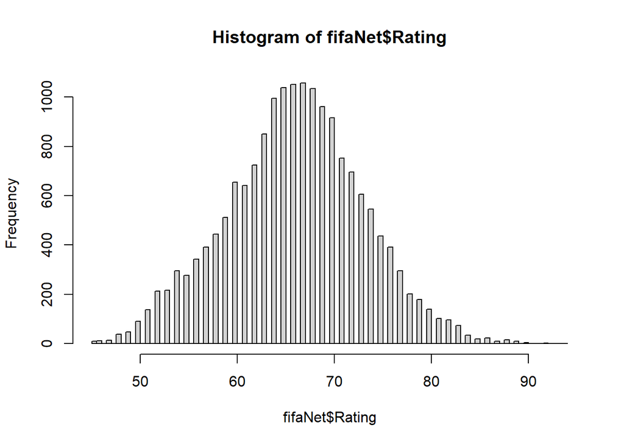

```r
# se usa la raiz cuadrada del numero de datos para establecer cuantas columnas usar
hist(fifaNet$Rating, breaks=sqrt(nrow(fifaNet)))
```

A la vista del histograma, **parece que esta variable sigue una distribución aproximadamente normal**, pero con la cola derecha algo menor que la izquierda. Para confirmar la normalidad, se puede realizar un **Q-Q plot** de los valores de *Rating*.

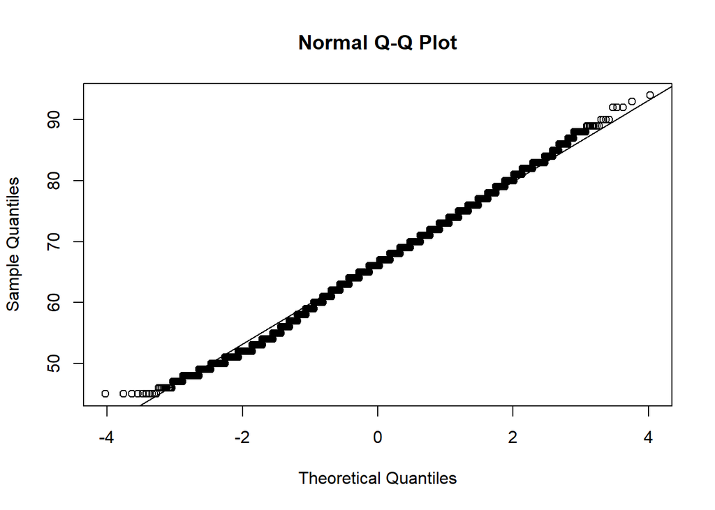

```r
qqnorm(fifaNet$Rating)
qqline(fifaNet$Rating)
```

Dado que los puntos se adaptan casi a la perfección a la recta en el QQ plot, y debido al tamaño elevado de la muestra, **asumimos normalidad de la variable *Rating*** por el teorema del límite central.

### 4.2.2 Contraste de hipótesis para la diferencia de medias

#### 4.2.2.1 Hipótesis nula y la alternativa

Se desea comprobar si la **valoración de los jugadores del Real Betis es 5 puntos menor que la de los jugadores del Real Madrid**. Para ello, las hipótesis para este caso se formulan del siguiente modo:

$$\left\{
\begin{array}{ll}
H_{0}: & \mu_m -\mu_b=5\\
H_{1}: & \mu_m-\mu_b>5\\
\end{array}
\right.$$
Siendo $\mu_{m}$ la media de la valoración de los jugadores del Real Madrid y $\mu_{b}$ la media de la valoración de los jugadores del Real Betis.

#### 4.2.2.2 Test a aplicar

El test a aplicar sería un **test unilateral sobre la diferencia de medias de dos muestras independientes (varianzas desconocidas)**. Es un **test unilateral por la derecha** porque la pregunta de investigación cuestiona si la media de los jugadores del Real Madrid es mayor a la de los jugadores del Real Betis.

#### 4.2.2.3 Aplicación y comprobación del test

Primeramente se deben obtener los datos de los jugadores del Real Madrid y Real Betis.

```r
betis_players = fifaNet$Rating[fifaNet$Club=="Real Betis"]
madrid_players = fifaNet$Rating[fifaNet$Club=="Real Madrid"]
length(betis_players)
```

```
## [1] 28
```

```r
length(madrid_players)
```

```
## [1] 33
```

Dado que acabamos de comprobar la normalidad de la variable *Rating*, podemos asumir que esta normalidad se trasladará a los dos subconjuntos.

Para concretar más aún el test que se va a realizar, será necesario realizar un **test de homoscedasticidad**, dado que se desconocen las varianzas poblacionales. Con este test se comprobará si las varianzas son iguales o diferentes.

```r
var.test(betis_players, madrid_players)
```

```
##
##  F test to compare two variances
##
## data:  betis_players and madrid_players
## F = 0.32757, num df = 27, denom df = 32, p-value = 0.004105
## alternative hypothesis: true ratio of variances is not equal to 1
## 95 percent confidence interval:
##  0.1583288 0.6937002
## sample estimates:
## ratio of variances
##          0.3275727
```

Dado que la hipótesis nula implica igualdad de varianzas, y el p-valor obtenido es inferior al nivel de significación $\alpha$ (0.05), se rechaza la hipótesis nula y **se asume que las varianzas son diferentes**.

Por tanto, el test a aplicar será una t de Student con $\upsilon$ grados de libertad, también llamado **test de Welch**.

```r
t.test(madrid_players,betis_players, var.equal = FALSE,alternative = "greater", mu = 5)
```

```
##
##  Welch Two Sample t-test
##
## data:  madrid_players and betis_players
## t = 0.042313, df = 52.248, p-value = 0.4832
## alternative hypothesis: true difference in means is greater than 5
## 95 percent confidence interval:
##  1.952377      Inf
## sample estimates:
## mean of x mean of y
##  78.75758  73.67857
```

## 4.3 Modelo de regresión lineal múltiple

Se desea estimar un **modelo de regresión lineal múltiple** que tenga como variables explicativas: Age, Weight, Club_Position, Vision, Ball_Control, Marking, Interceptions, Freekick_Accuracy, Short_Pass, Speed y Finishing; y como **variable dependiente el Rating de los jugadores**. Antes de realizar el modelo será necesario establecer el nivel base de referencia en la variables categórica *Club_Position*.

```r
# Fijamos como valor referencia el valor mayoritarío para variable cat.
fifaNet$Club_Position = relevel(factor(fifaNet$Club_Position), ref=max(fifaNet$Club_Position))

# Modelo lineal Multiple
multi_model_1 = lm(Rating~Age+Weight+Club_Position+Vision+Ball_Control+Marking+Interceptions+Freekick_Accuracy+Short_Pass+Speed+Finishing,data=fifaNet)
summary(multi_model_1)
```

```
##
## Call:
## lm(formula = Rating ~ Age + Weight + Club_Position + Vision +
##     Ball_Control + Marking + Interceptions + Freekick_Accuracy +
##     Short_Pass + Speed + Finishing, data = fifaNet)
##
## Residuals:
##      Min       1Q   Median       3Q      Max
## -17.9581  -3.0895  -0.1554   2.8687  25.7490
##
## Coefficients:
##                    Estimate Std. Error t value Pr(>|t|)
## (Intercept)       18.786898   0.587890  31.957  < 2e-16 ***
## Age                0.390068   0.008988  43.397  < 2e-16 ***
## Weight             0.228125   0.006012  37.942  < 2e-16 ***
## Club_PositionCAM   1.040726   0.275926   3.772 0.000163 ***
## Club_PositionCB    1.964848   0.521962   3.764 0.000168 ***
## Club_PositionCDM   0.107616   0.438474   0.245 0.806124
## Club_PositionCF   -0.392575   2.346569  -0.167 0.867138
## Club_PositionCM   -0.732966   0.533238  -1.375 0.169286
## Club_PositionGK    9.241518   0.225552  40.973  < 2e-16 ***
## Club_PositionLAM   1.829559   0.785965   2.328 0.019935 *
## Club_PositionLB    0.515096   0.214320   2.403 0.016254 *
## Club_PositionLCB   2.444769   0.205470  11.898  < 2e-16 ***
## Club_PositionLCM  -0.632939   0.260088  -2.434 0.014961 *
## Club_PositionLDM  -0.296895   0.298288  -0.995 0.319589
## Club_PositionLF    1.797703   1.356297   1.325 0.185039
## Club_PositionLM    0.809327   0.241336   3.354 0.000800 ***
## Club_PositionLS    0.750305   0.339220   2.212 0.026990 *
## Club_PositionLW    3.050338   0.415095   7.349 2.09e-13 ***
## Club_PositionLWB  -0.157057   0.703568  -0.223 0.823359
## Club_PositionRAM   1.237241   0.786028   1.574 0.115496
## Club_PositionRB    0.500209   0.214895   2.328 0.019940 *
## Club_PositionRCB   2.683627   0.205722  13.045  < 2e-16 ***
## Club_PositionRCM  -0.949626   0.260464  -3.646 0.000267 ***
## Club_PositionRDM  -0.125340   0.298421  -0.420 0.674484
## Club_PositionRes  -1.292462   0.103450 -12.494  < 2e-16 ***
## Club_PositionRF    2.325213   1.356545   1.714 0.086534 .
## Club_PositionRM    0.949658   0.240885   3.942 8.10e-05 ***
## Club_PositionRS    0.894071   0.338019   2.645 0.008176 **
## Club_PositionRW    2.870634   0.414476   6.926 4.48e-12 ***
## Club_PositionRWB  -0.412686   0.703273  -0.587 0.557341
## Club_PositionST    2.775464   0.246406  11.264  < 2e-16 ***
## Vision             0.109078   0.004434  24.603  < 2e-16 ***
## Ball_Control       0.102363   0.006819  15.011  < 2e-16 ***
## Marking           -0.059506   0.004623 -12.873  < 2e-16 ***
## Interceptions      0.075754   0.004765  15.896  < 2e-16 ***
## Freekick_Accuracy -0.019174   0.003517  -5.451 5.06e-08 ***
## Short_Pass         0.111432   0.006577  16.942  < 2e-16 ***
## Speed              0.048610   0.003801  12.787  < 2e-16 ***
## Finishing         -0.036045   0.004171  -8.641  < 2e-16 ***
## ---
## Signif. codes:  0 '***' 0.001 '**' 0.01 '*' 0.05 '.' 0.1 ' ' 1
##
## Residual standard error: 4.69 on 17548 degrees of freedom
## Multiple R-squared:  0.5624, Adjusted R-squared:  0.5614
## F-statistic: 593.4 on 38 and 17548 DF,  p-value: < 2.2e-16
```

Para una mejor diagnosis del modelo, se toma el modelo construído y **se realiza un estudio de sus residuos**. Los residuos se definen como **la diferencia entre los valores observados en la muestra y los valores estimados por el modelo**. Los valores que tomen estos residuos determinarán la adecuación del modelo.

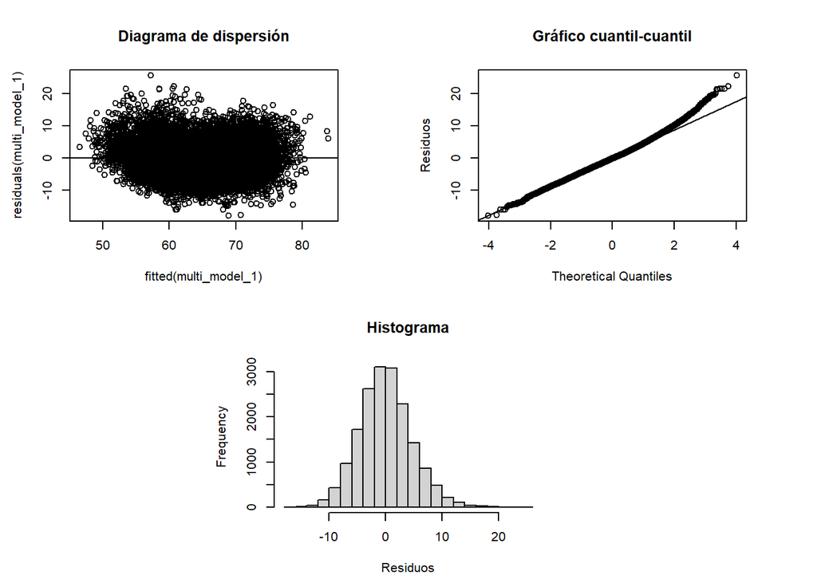

```r
# Valores ajustados vs Residuos
par(mai=rep(0.6, 4))
layout(matrix(c(1,1, 2,2, 0, 3,3, 0), ncol = 4, byrow = TRUE))
plot(fitted(multi_model_1), residuals(multi_model_1), main="Diagrama de dispersión")
abline(h=0)
# QQ plot
qqnorm(residuals(multi_model_1), ylab="Residuos", main="Gráfico cuantil-cuantil")
qqline(residuals(multi_model_1))
# Histograma para comprobar normalidad
hist(residuals(multi_model_1), xlab = "Residuos", main="Histograma")
```

### 4.3.1 Interpretación del modelo

De las variables utilizadas todas **resultan signficativas (p<0.05)** a excepción de alguna de las demarcaciones del jugador en su club. Respecto a las demás:

- La edad, el peso, la vision, el control del balón, las interecpciones, pases cortos y velocidad **influyen positivamente** en el rating.
- Algunas posiciones como ser portero influye positivamente en el rating. Esto tiene sentido, ya que no se ha introducido ninguno de los atributos propios de porteros y por tanto, a pesar de tener valores más bajos, obtienen mejores medias.
- El marcaje, la precisión de tiro libre y la finalización **influyen de manera negativa** en el rating.

## 4.4 Regresión logística

Utilizando diferentes variables explicativas, como *Age* o *Rating*, se ajusta un **modelo predictivo basado en regresión logística** para predecir la **probabilidad de que un jugador vaya a la selección** de su país. Para que la muestra sea más homogénea, este modelo se realizará solo con **jugadores españoles** (Nationality == Spain).

Primero de todo, generaremos y usaremos la **variable dicotómica ‘internacional’**. Esta variable tomará el valor **1 si el jugador forma parte de la selección** de su país, y 0 en el caso contrario.

```r
fifaNet$internacional[is.na(fifaNet$National_Kit)] = 0
fifaNet$internacional[!is.na(fifaNet$National_Kit)] = 1
```

Para conseguir un mejor modelo, generaremos **otra variable dicotómica, esta vez llamada ‘portero’**, para diferenciar los jugadores de campo (‘Jugador’) y los porteros (‘Portero’).

```r
fifaNet$portero[fifaNet$Club_Position=="GK"] = "Portero"
fifaNet$portero[fifaNet$Club_Position!="GK"] = "Jugador"
fifaNet$portero = as.factor(fifaNet$portero)
```

Filtramos el dataset original (fifaNet) para generar un segundo dataset solo con **jugadores españoles (fifaNet_spain)**. Será con este set de datos con el que se ajuste el modelo predictivo.

```r
fifaNet_spain = fifaNet[fifaNet$Nationality == "Spain" , ]
```

Se realiza una 20-fold cross-validation mediante la función **trainControl()** del paquete *caret*.

```r
# 20-fold cv
fitControl = trainControl(method = "cv", number = 20, savePredictions = T)
# Ajuste del modelo (regresión logistica)
model_fit = train(internacional~Age+Rating+portero+Work_Rate,data=fifaNet_spain, method = "glm", family="binomial", trControl = fitControl)

# Valores predichos y observados
pred_prob = (model_fit$pred)$pred
pred_bin = factor(ifelse(pred_prob >= 0.5, 1, 0))
obs_bin = factor((model_fit$pred)$obs)

# Matriz de confusión
confusionMatrix(table(pred_bin,obs_bin), positive = "1")
```

```
## Confusion Matrix and Statistics
##
##         obs_bin
## pred_bin   0   1
##        0 980   6
##        1   5  17
##
##                Accuracy : 0.9891
##                  95% CI : (0.9806, 0.9945)
##     No Information Rate : 0.9772
##     P-Value [Acc > NIR] : 0.004098
##
##                   Kappa : 0.75
##
##  Mcnemar's Test P-Value : 1.000000
##
##             Sensitivity : 0.73913
##             Specificity : 0.99492
##          Pos Pred Value : 0.77273
##          Neg Pred Value : 0.99391
##              Prevalence : 0.02282
##          Detection Rate : 0.01687
##    Detection Prevalence : 0.02183
##       Balanced Accuracy : 0.86703
##
##        'Positive' Class : 1
##
```

### 4.4.1 Interpretación del modelo

Consideramos que hemos conseguido **un buen modelo para predecir si un jugador español es convocado o no por la selección**.

Se observa una estimación de la **precisión del modelo en torno al 99%**, lo cual es una precisión muy buena. Por otra parte, si se analiza la **sensibilidad, se observa que es del 74%**. Aunque está lejos del valor que toma la precisión, la posibilidad de acertar si un jugador seleccionado por su selección es aceptable Por último, la **especificidad es casi del 100%**, es decir, la posibilidad de detectar realmente los casos en los que no irá a la selección es casi perfecta.

# 5 Conclusiones